# Data Visualisations for Bioinformatics in R

Karsten Hokamp & Fiona Roche

18 April 2018

## Setup

The code below uses a couple of libraries that might need to be installed first:

```r
#options(repos = c("https://mirrors.ebi.ac.uk/CRAN/"))
#install.packages('ggfortify')
#install.packages('ggplot2')
# DESeq2 is a BioConductor package:
#source("https://bioconductor.org/biocLite.R")
#biocLite("DESeq2")
```

## Setting the scene

- expression of genes measured on a genome scale (previously microarrays now mostly RNA-seq)
- thousands of measurements for each sample
- multiple replicates per condition/strain/timepoint
- need ways to quickly get an overview of how individual samples compare to each other

## PCA plots

- dimension reduction: compressing loads of data into simple output that captures main trends from the original data
- useful to detect sample outliers or mis-labelling

Let’s start with a small synthetic data set to demonstrate this (two sets of five samples, 100 genes, taken from statquest.org):

```r
data.matrix <- matrix(nrow=100, ncol=10)
colnames(data.matrix) <- c(paste("wt", 1:5, sep=''), paste('ko', 1:5, sep=''))
rownames(data.matrix) <- paste('gene', 1:100, sep='')
for (i in 1:100) {
  wt.values <- rpois(5, lambda=sample(x=10:1000, size=1))
  ko.values <- rpois(5, lambda=sample(x=10:1000, size=1))
  data.matrix[i,] <- c(wt.values, ko.values)
}
head(data.matrix)
```

```
##       wt1 wt2 wt3 wt4 wt5 ko1 ko2 ko3 ko4  ko5
## gene1 846 890 869 933 945 803 842 843 830  834
## gene2 621 642 615 637 581 545 558 588 556  536
## gene3 157 159 164 147 155 520 532 549 563  534
## gene4 898 910 948 956 923 175 187 206 206  165
## gene5 516 493 490 493 502 914 981 982 961  986
## gene6 486 532 510 471 551 943 940 995 941 1017
```

Just from eye-balling the data set one can see similarities amongst the replicates (1-5) and differences between the two groups (wild-type and knock-out).

Here is how to calculate the principal components and plot some info:

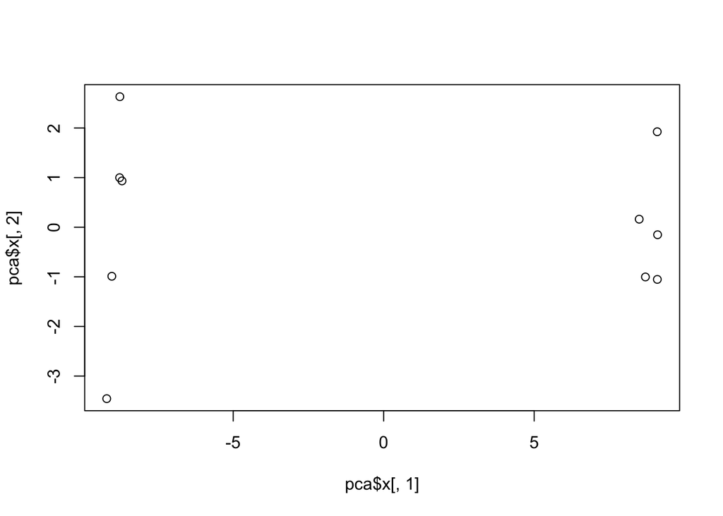

```r
pca <- prcomp(t(data.matrix), scale=TRUE)
plot(pca$x[,1], pca$x[,2])
```

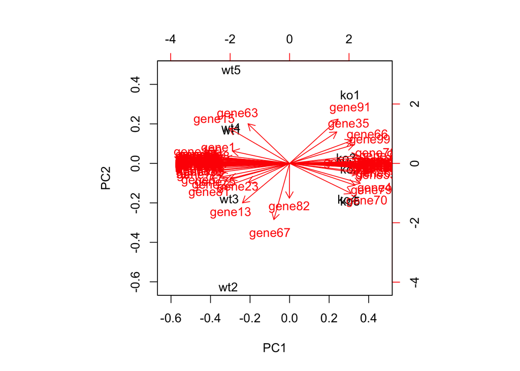

```r
biplot(pca)
```

Loads of info from biplot, bit too little from the simpler plot.

Let’s plot PC1 and PC2 with the samples (including labels) using ggplot2:

```r
pca.data <- data.frame(Sample=rownames(pca$x),
                       X=pca$x[,1],
                       Y=pca$x[,2])
library(ggplot2, quietly=TRUE)
```

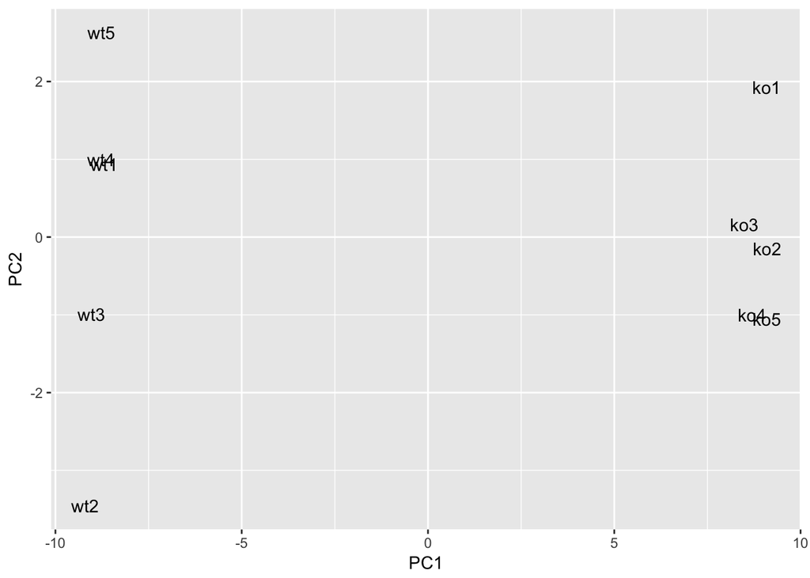

```r
ggplot(data=pca.data, aes(x=X, y=Y, label=Sample)) +
  geom_text() +
  xlab("PC1") +
  ylab("PC2")
```

Interested in the percentage of variation explained by each PC?

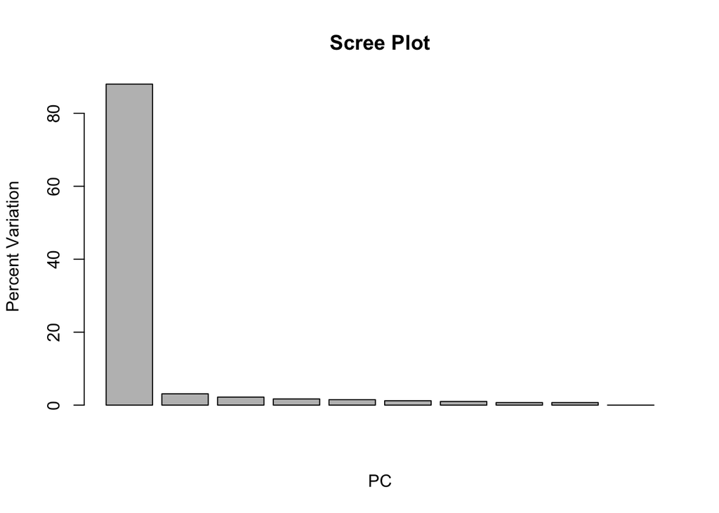

```r
pca.var <- pca$sdev^2
pca.var.per <- round(pca.var/sum(pca.var)*100, 1)
barplot(pca.var.per, main='Scree Plot', xlab='PC', ylab='Percent Variation')
```

Let’s add this to the axis label:

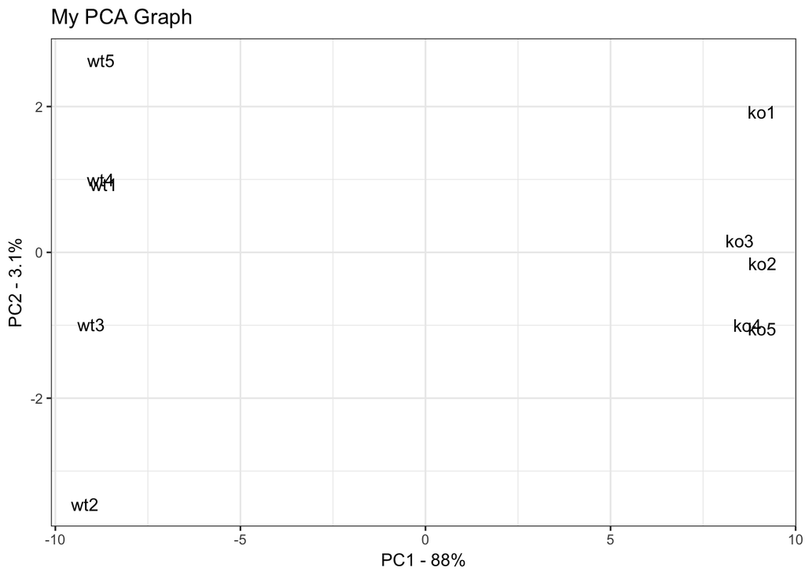

```r
ggplot(data=pca.data, aes(x=X, y=Y, label=Sample)) +
  geom_text() +
  xlab(paste("PC1 - ", pca.var.per[1], "%", sep='')) +
  ylab(paste("PC2 - ", pca.var.per[2], "%", sep='')) +
  theme_bw() +
  ggtitle("My PCA Graph")
```

In case you’re interested you can show which genes are the top drivers for the separation of samples along PC1:

```r
loading_scores <- pca$rotation[,1]
gene_scores <- abs(loading_scores)
gene_score_ranked <- sort(gene_scores, decreasing=TRUE)
top_10_genes <- names(gene_score_ranked[1:10])
pca$rotation[top_10_genes,1]
```

```
##     gene40      gene8     gene84     gene45     gene86      gene4
##  0.1065668 -0.1065613 -0.1065564  0.1065514  0.1065359 -0.1064982
##     gene85     gene52     gene41     gene29
##  0.1064898 -0.1064800 -0.1064709 -0.1064696
```

```r
data.matrix[top_10_genes,]
```

```
##        wt1  wt2  wt3 wt4  wt5 ko1 ko2 ko3 ko4 ko5
## gene40  65   67   49  55   53 770 782 771 781 800
## gene8  778  780  778 786  760 103  86  99 103 110
## gene84 501  527  504 515  507 135 132 138 142 142
## gene45  76   74   62  69   64 967 933 893 935 918
## gene86  72   81   79  86   76 629 658 647 649 659
## gene4  898  910  948 956  923 175 187 206 206 165
## gene85 238  256  242 234  230 964 921 950 928 944
## gene52 978 1029 1021 972 1007 346 348 384 392 332
## gene41 757  749  802 732  740  74  64  67  80  77
## gene29 922  987  952 938  916 329 343 350 347 306
```

## Real data

It’s not always so clear cut with real data!

```r
# library data.table provides 'fread' to get data from web
library(data.table)
```

```r
# download data from URL or from local file
web <- fread('http://bioinf.gen.tcd.ie/rclub/rna-seq_input.txt', header=TRUE)
real.data <- data.frame(web[,-1], row.names=web$Gene)
#real.data <- read.table(file='rna-seq_input.txt',sep="\t")
head(real.data)
```

```
##                      ab1   ab2   ab3   ab4   ab5    xx1   xx2   xx3   xx4
## ENSMUST00000074761 55428 72403  4801 42620 36563   3514 23128 51321 33647
## ENSMUST00000183422 25792 25502  4702 15754 12449   2875  7931 18641 11751
## ENSMUST00000103410 37487 32684 58556 61646 53528 115767 88395 25706 33190
## ENSMUST00000093207   262   102   289   458   106  39581 12776 93588 23925
## ENSMUST00000099683 70540 36180   759 20410 40598   3104 26549 16742 26578
## ENSMUST00000103426  4772  3963  5581 11552 10843  27351 36143  4883  7937
##                      xx5 ctrl1 ctrl2 ctrl3 ctrl4 ctrl5   ba1   ba2   ba3
## ENSMUST00000074761 59330 58492 28160 48065 17990 69099 64721 66107 47824
## ENSMUST00000183422 21282 22761 15062 22512  9130 29255 27038 25993 15894
## ENSMUST00000103410 28754  6929 10221  9710  4772  5316  6388  5692  9189
## ENSMUST00000093207 11076    76    62   312    97  1294   221   177   143
## ENSMUST00000099683 20213 24746 12206 35776 18913 25292 43739 19416 27747
## ENSMUST00000103426  6360   342   366   317   242   427   270   233   332
##                      ba4   ba5
## ENSMUST00000074761 50789 40500
## ENSMUST00000183422 17591 14322
## ENSMUST00000103410 66694  5387
## ENSMUST00000093207 41076   293
## ENSMUST00000099683 35689 41871
## ENSMUST00000103426 18752   308
```

```r
# get description of samples
web <- fread('http://bioinf.gen.tcd.ie/rclub/samples.txt', header=TRUE)
sample <- data.frame(web[,-1], row.names=web$Sample)
#sample <- read.table('samples.txt', header=T, sep="\t", row.names = 1)
factor(sample$Condition)
```

```
##  [1] ab   ab   ab   ab   ab   xx   xx   xx   xx   xx   ctrl ctrl ctrl ctrl
## [15] ctrl ba   ba   ba   ba   ba
## Levels: ab ba ctrl xx
```

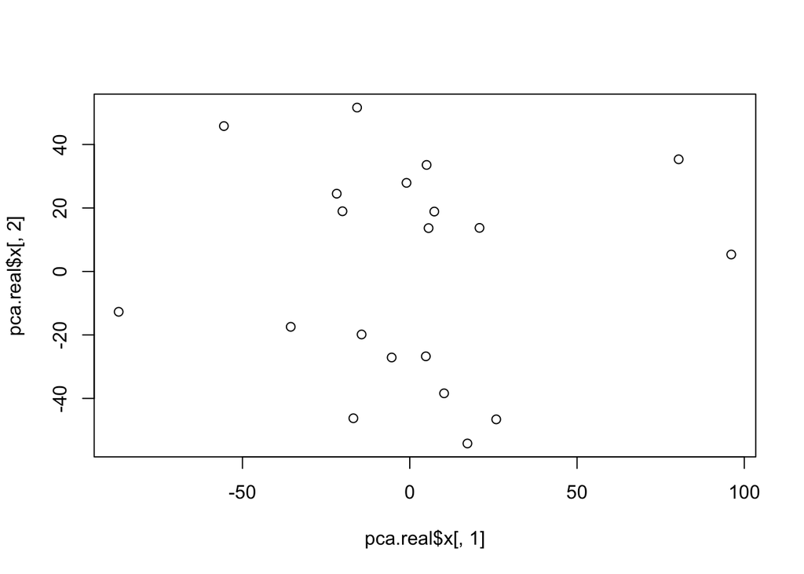

```r
# add pseudo-count, then log-transform
real.data.log2 <- log2(real.data+1)

# run prcomp on transposed matrix to calculate principle components
pca.real <- prcomp(t(real.data.log2))
plot(pca.real$x[,1], pca.real$x[,2])
```

Quite the clutter - definitely needs labels:

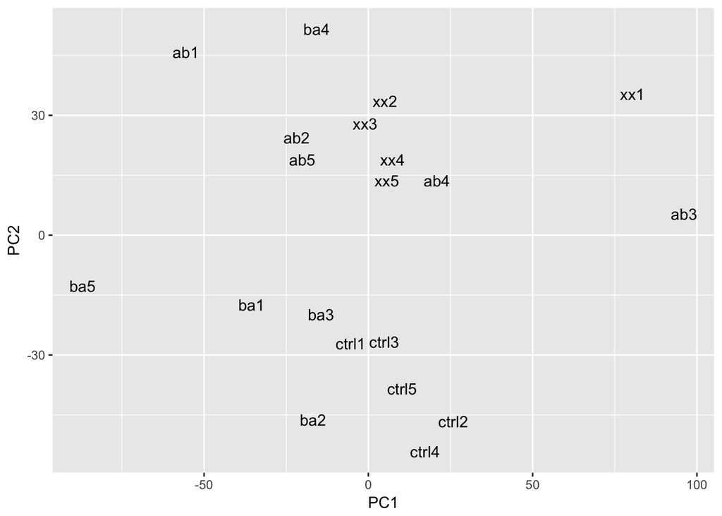

```r
pca.real.data <- data.frame(Sample=rownames(pca.real$x),
                       X=pca.real$x[,1],
                       Y=pca.real$x[,2])

ggplot(data=pca.real.data, aes(x=X, y=Y, label=Sample)) +
  geom_text() +
  xlab("PC1") +
  ylab("PC2")
```

One could now go into ggplot2 to add colours etc. but there is an easier way:

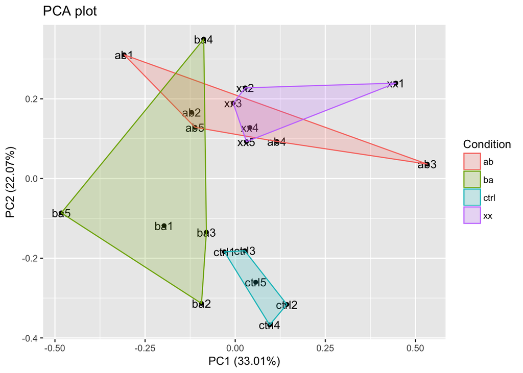

```r
library(ggfortify, quietly=TRUE)
autoplot(pca.real, data = sample, main = 'PCA plot', label=TRUE, frame = TRUE, frame.colour = 'Condition')
```

From the help page:

“ggfortify helps plotting some popular R packages with ggplot2 in a unified way.”

“Rather than using this function, I now recomend using the broom package, which implements a much wider range of methods. fortify may be deprecated in the future.”

There is more than one way to do this and the downstream analysis tools bring their own function, for example DESeq2:

```r
library(DESeq2, quietly=TRUE)
```

```r
# some sanity checks:
all(rownames(sample) %in% colnames(real.data))
```

```
## [1] TRUE
```

```r
all(rownames(sample) == colnames(real.data))
```

```
## [1] TRUE
```

```r
# creating the DESeq object:
dds <- DESeqDataSetFromMatrix(countData = real.data, colData = sample, design = ~ Condition)
```

```r
# normalisation
dds <- DESeq(dds)
```

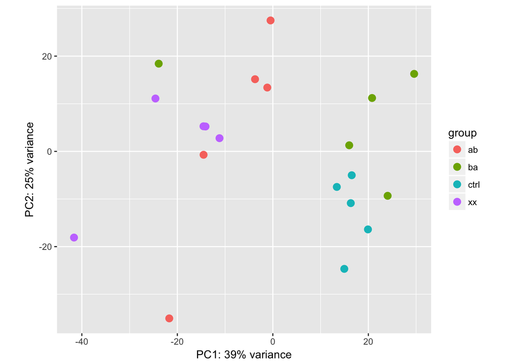

```r
# transformation and PCA (only the top 500 genes are used)
rld <- rlog(dds, blind=FALSE)
plotPCA(rld, intgroup=c('Condition'))
```

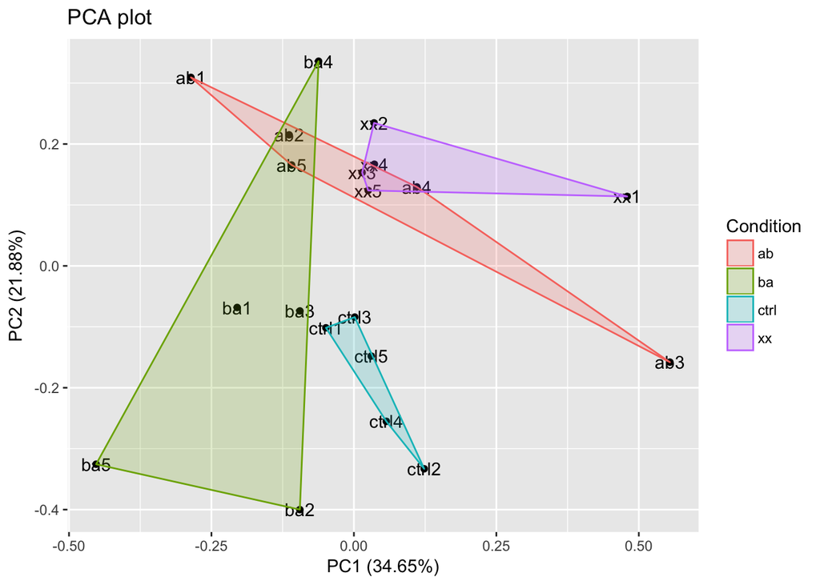

```r
# PCA plot with prcomp and autoplot on normalised data:
norm <- counts(dds, normalized=TRUE)
norm.log2=log2(norm+1)
pca <- prcomp(t(norm.log2))
autoplot(pca, data = sample, main = 'PCA plot', label=TRUE, frame = TRUE, frame.colour = 'Condition')
```

Also see devtool ‘ggbiplot’: https://github.com/vqv/ggbiplot There is an experimental branch of ggbiplot that is “a complete overhaul of the existing ggbiplot package” but hasn’t had any commits for the last three years.